# NYC_tidy

Waheeb Algabri

2023-03-09

load required libraries

```r
library(tidyverse)
```

```r
library(dplyr)
library(knitr)
library(tidytext)
library(stringr)
library(ggwordcloud)
```

Read the data

```r
NYC_Jobs_2 <- read_csv("data/NYC_Jobs-2.csv")
head(NYC_Jobs_2)
```

```
## # A tibble: 6 × 23
##   `Job ID` Agency  Posti…¹ # Of …² Busin…³ Civil…⁴ Title…⁵ Level Salar…⁶ Salar…⁷
##      <dbl> <chr>   <chr>     <dbl> <chr>   <chr>   <chr>   <chr>   <dbl>   <dbl>
## 1   562892 DEPT O… Extern…       1 Inspec… PUBLIC… 31215   01      45722   45722
## 2   572708 DEPT O… Intern…       1 Superv… ASSOCI… 31220   02      67335  101875
## 3   572754 DEPART… Intern…       7 City A… CITY A… 40202   3A      93519   93519
## 4   568275 OFF OF… Intern…       1 Fiduci… STAFF … 12626   02      62470   80000
## 5   562276 ADMIN … Intern…       1 Assist… EXECUT… 95005   M1      63301  106350
## 6   556907 OFFICE… Intern…       1 Consti… COMMUN… 56058   00      70000   80000
## # … with 13 more variables: `Salary Frequency` <chr>, `Work Location` <chr>,
## #   `Division/Work Unit` <chr>, `Job Description` <chr>,
## #   `Minimum Qual Requirements` <chr>, `Preferred Skills` <chr>,
## #   `Additional Information` <chr>, `To Apply` <chr>, `Hours/Shift` <chr>,
## #   `Work Location 1` <chr>, `Recruitment Contact` <lgl>,
## #   `Residency Requirement` <chr>, `Post Until` <chr>, and abbreviated variable
## #   names ¹`Posting Type`, ²`# Of Positions`, ³`Business Title`, …
```

```r
# extract necessary columns
selected_data <- NYC_Jobs_2 %>%
  select(`Job ID`, `Business Title`, `Job Description`, `Salary Range From`, `Salary Range To`, `Work Location`)
```

This code will select the Job Description column from the selected_data data frame, tokenize the words in each description using unnest_tokens(), remove any non-alphanumeric characters, and remove stop words using the filter() function. This will give us a tidy data frame of all the words in our job descriptions that are not stop words. From here, we can perform further analysis on these words to identify the most common data science skills.

```r
# Load required libraries
library(tidytext)
library(dplyr)
library(stringr)

# Clean and tokenize job descriptions
selected_data %>%
  select(`Job Description`) %>%
  unnest_tokens(word,`Job Description`) %>%
  mutate(word = str_replace_all(word, "[^[:alnum:]']", "")) %>%
  filter(!word %in% stop_words$word)
```

```
## # A tibble: 1,488,492 × 1
##    word
##    <chr>
##  1 york
##  2 city
##  3 department
##  4 health
##  5 mental
##  6 hygiene's
##  7 division
##  8 environmental
##  9 health
## 10 prevent
## # … with 1,488,482 more rows
```

```r
# extract salary information
selected_data$MinSalaries <- as.numeric(str_extract(selected_data$`Salary Range From`, "\\d+"))
selected_data$MaxSalaries <- as.numeric(str_extract(selected_data$`Salary Range To`, "\\d+"))
selected_data$MeanSalary <- rowMeans(selected_data[,c("MinSalaries", "MaxSalaries")], na.rm = TRUE)

# filter out rows with missing salary information
selected_data <- selected_data %>%
  filter(!is.na(MinSalaries) & !is.na(MaxSalaries))

# see ranges of mean salaries
range(selected_data$MeanSalary)
```

```
## [1]      0.5 231796.0
```

```r
OneHundredToTwoHundredK <- selected_data %>% filter(selected_data$MeanSalary>=100 & selected_data$MeanSalary<=200)


LessThanUSMeanSalary <- selected_data %>% filter(selected_data$MeanSalary < 51.9)
UpperEchelon <- selected_data %>% filter(selected_data$MeanSalary > 200)
```

Upper Echelon Key Characteristics

```r
# tokenize and clean job descriptions for Upper Echelon salaries
description <- data.frame(UpperEchelon$`Job Description`)
desclist <- unlist(description)
desclist <- str_remove_all(desclist, '[[:punct:]]')
desclist <- str_remove_all(desclist, '[\r\n]')
desclist <- str_remove_all(desclist, '[0-9]')
desclist <- str_remove_all(desclist, '[\r\n]')
desclist <- tolower(desclist)
descsplit <- strsplit(desclist, " ")
```

```r
# count word frequencies
frequenciesUE <- table(unlist(descsplit))
frequenciesUE <- data.frame(frequenciesUE)
colnames(frequenciesUE) <- c('word', 'count')
```

```r
# omit frequently occurring words
omit <- c(" ", "and", "with", "from", "for", "the", "our", "your", "are", "will", "with", "that", "other", "all", "have", "to", "of", "", "this", "you", "a", "in", "is", "or", "as", "on", "be", "we", "by", "at", "an", "their", "us", "it", "can", "who", "such", "through", "into", "including", "one", "two", "three", "four", "five", "six", "not")
frequenciesUE <- subset(frequenciesUE, as.numeric(count) >= 3)
frequenciesUE_relevant <- frequenciesUE[!frequenciesUE$word %in% omit, ]
```

```r
# sort words by frequency in descending order
frequenciesUE_relevant <- frequenciesUE_relevant[order(-frequenciesUE_relevant$count), ]
```

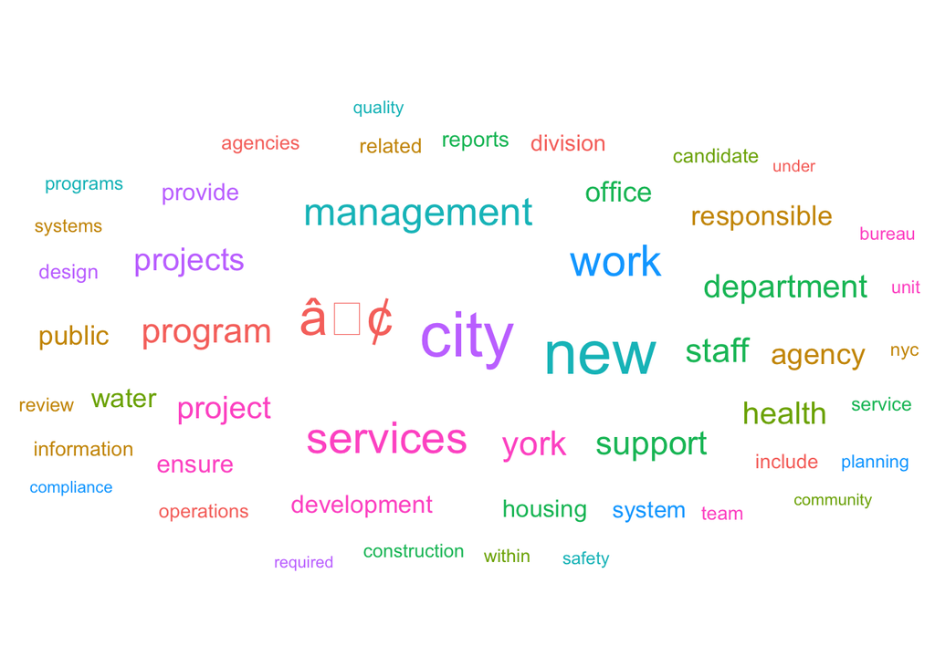

```r
# plot top 50 frequent words
overweighted <- c("data", "analyst", "analysis", "analytics")
freqplot <- frequenciesUE_relevant[!frequenciesUE_relevant$word %in% overweighted, ]
freqplot <- freqplot[1:50, ]
ggplot(freqplot, aes(label = word, size = count, color = factor(sample.int(8, nrow(freqplot), replace = TRUE))))+
  geom_text_wordcloud()+
  scale_radius(range = c(0, 12), limits = c(0, NA)) +
  theme_minimal()
```

Lowest Income Key Characteristics

```r
# tokenize and clean job descriptions for salaries less than or equal to US mean
description <- data.frame(selected_data %>% filter(MeanSalary <= mean(selected_data$MeanSalary)) %>% select(`Job Description`))
desclist <- unlist(description)
desclist <- str_remove_all(desclist, '[[:punct:]]')
desclist <- str_remove_all(desclist, '[\r\n]')
desclist <- str_remove_all(desclist, '[0-9]')
desclist <- str_remove_all(desclist, '[\r\n]')
desclist <- tolower(desclist)
descsplit <- strsplit(desclist, " ")

# count word frequencies
frequenciesUSMean <- table(unlist(descsplit))
frequenciesUSMean <- data.frame(frequenciesUSMean)
colnames(frequenciesUSMean) <- c('word', 'count')

# omit infrequently occurring words
frequenciesUSMean <- subset(frequenciesUSMean, as.numeric(count) >= 3)

# omit stop words
omit <- c(" ", "and", "with", "from", "for", "the", "our", "your", "are", "will", "with", "that", "other", "all", "have", "to", "of", "", "this", "you", "a", "in", "is", "or", "as", "on", "be", "we", "by", "at", "an", "their", "us", "it", "can", "who", "such", "through", "into", "including", "one", "two", "three", "four", "five", "six", "not")
frequenciesUSMean_relevant <- frequenciesUSMean[!frequenciesUSMean$word %in% omit, ]
```

[figure not shown]

```r
# plot top 50 frequent words
overweighted <- c("data", "analyst", "analysis", "analytics")
freqplot <- frequenciesUSMean_relevant[!frequenciesUSMean_relevant$word %in% overweighted, ]
freqplot <- freqplot[1:50, ]
ggplot(freqplot, aes(label = word, size = count, color = factor(sample.int(8, nrow(freqplot), replace = TRUE))))+
  geom_text_wordcloud()+
  scale_radius(range = c(0, 12), limits = c(0, NA)) +
  theme_minimal()
```

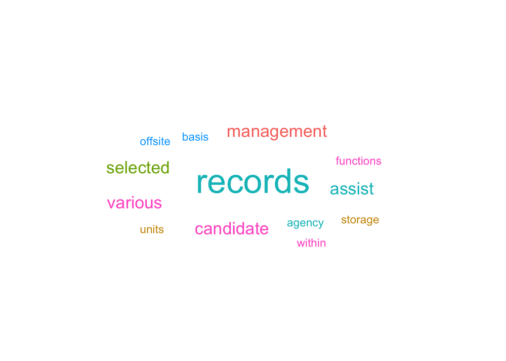

```r
# Tokenize and clean job descriptions for salaries between $100,000 and $200,000
description <- data.frame(OneHundredToTwoHundredK %>% select(`Job Description`))
desclist <- unlist(description)
desclist <- str_remove_all(desclist, '[[:punct:]]')
desclist <- str_remove_all(desclist, '[\r\n]')
desclist <- str_remove_all(desclist, '[0-9]')
desclist <- str_remove_all(desclist, '[\r\n]')
desclist <- tolower(desclist)
descsplit <- strsplit(desclist, " ")

# Count word frequencies
frequencies100to200K <- table(unlist(descsplit))
frequencies100to200K <- data.frame(frequencies100to200K)
colnames(frequencies100to200K) <- c('word', 'count')

# Omit frequently occurring words
omit <- c(" ", "and", "with", "from", "for", "the", "our", "your", "are", "will", "with", "that", "other", "all", "have", "to", "of", "", "this", "you", "a", "in", "is", "or", "as", "on", "be", "we", "by", "at", "an", "their", "us", "it", "can", "who", "such", "through", "into", "including", "one", "two", "three", "four", "five", "six", "not")
frequencies100to200K <- subset(frequencies100to200K, as.numeric(count) >= 3)
frequencies100to200K_relevant <- frequencies100to200K[!frequencies100to200K$word %in% omit, ]

# Sort words by frequency in descending order
frequencies100to200K_relevant <- frequencies100to200K_relevant[order(-frequencies100to200K_relevant$count), ]

# Plot top 50 frequent words
overweighted <- c("data", "analyst", "analysis", "analytics")
freqplot <- frequencies100to200K_relevant[!frequencies100to200K_relevant$word %in% overweighted, ]
freqplot <- freqplot[1:50, ]
ggplot(freqplot, aes(label = word, size = count, color = factor(sample.int(8, nrow(freqplot), replace = TRUE))))+
  geom_text_wordcloud()+
  scale_radius(range = c(0, 12), limits = c(0, NA)) +
  theme_minimal()
```

```r
head(freqplot)
```

```
##          word count
## 46    records    12
## 8      assist     6
## 12  candidate     6
## 33 management     6
## 51   selected     6
## 68    various     6
```

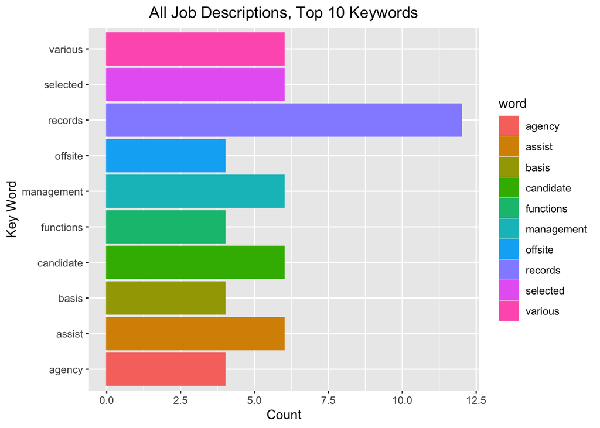

```r
freqbar <- freqplot[1:10, ]
ggplot(freqbar, aes(x = word, y = count, color = word, fill = word))+
  geom_col()+
  ggtitle("All Job Descriptions, Top 10 Keywords") +
  xlab("Key Word")+
  ylab("Count")+
  theme(plot.title = element_text(hjust = 0.5))+
  coord_flip()
```

# Conclusion

In this code, we first loaded the required libraries for data analysis, including tidyverse, dplyr, knitr, tidytext, stringr, and ggwordcloud. We then read in the data from a CSV file using the read_csv() function from the readr package.

Next, we selected the necessary columns from the data frame, including Job ID, Business Title, Job Description, Salary Range From, Salary Range To, and Work Location. We then used the unnest_tokens() function from tidytext to tokenize the words in the Job Description column, removed any non-alphanumeric characters, and filtered out stop words using filter(). This resulted in a tidy data frame of all the words in our job descriptions that are not stop words.

We then extracted salary information from the data frame and filtered out rows with missing salary information. We also looked at the range of mean salaries in the data and created subsets of the data based on specific salary ranges.